# Datos generados por deliveries y sus usos

Francisco Vega

25-11-2021

## Resumen

Los deliveries generan datos importantes para la toma de decisiones. Por lo que, en este trabajo se busca ver que decisiones se pueden tomar en una pastelería en Corea del Sur. Los datos utilizados poseen información sobre la fecha y hora, el total en wones sur-coreanos y los productos solicitados. Los resultados obtenidos nos presentan los días con mayor cantidad de ventas, producto mas vendido y el rango de horario mas popular. Las decisiones que se pueden tomar con los datos obtenidos van desde creación de promociones hasta cambios en el horario de atención.

## Abstract

Deliveries generate important data for decision making. Therefore, in this paper we seek to see what decisions can be made in a South Korean bakery. The data used has information about the date and time, the total in South Korean won and the products ordered. The results obtained show the days with the highest number of sales, the most sold product and the most popular time range. The decisions that can be made with the data obtained range from the creation of promotions to changes in the opening hours.

## Introducción

En el mundo actual hay muchos datos que se recopilan de forma automática. Un ejemplo de esto son los deliveries, de los que se puede obtener información sobre la hora del pedido, que productos fueron solicitados, el valor total, etc. Pero ¿qué se puede hacer con estos datos? Los datos nos pueden decir muchas cosas. Siguiendo con el ejemplo de los deliveries, podemos obtener una lista con los productos más vendidos, analizar a qué hora hay más pedidos e incluso ver desde donde se realizan más solicitudes.

Con estos datos se pueden tomar decisiones corporativas en diferentes restaurantes o pastelerías, como, por ejemplo, poner una sucursal más cerca de un sector o cambiar los horarios de turnos para tener mayor personal en un horario punta y menos personal en un horario en el que no hay muchos pedidos.

Es por esto que, en este informe se analizarán datos provenientes de una pastelería en Corea del Sur, para poder responder una serie de preguntas que nos permitirán ver la forma en la que distintas decisiones pueden ser tomadas con las respuestas obtenidas.

Para ello, primero se presentará la base de datos y se darán detalles sobre sus variables. Luego se hará un manejo de datos para poder analizarlos y poder responder las preguntas con los resultados de los diferentes análisis. Finalmente, se concluirá cómo estos datos pueden darnos la información necesaria para la toma de decisiones dentro de la pastelería.

## Datos

En este informe se analizarán datos provenientes de una pastelería en Corea del Sur, cuyos datos fueron obtenidos de la página web Kaggle[^1] y fueron recopilados por el usuario “Hosub Jeong”, la cual a través de deliveries recabó información sobre fechas y horas, productos vendidos, el monto total vendido en wones sur-coreanos y sector de donde se realizó el pedido. Estos datos están representados en 27 columnas las cuales podemos ver a continuación:

Columnas de datos

[output not shown]

Por último, la pastelería no abre los martes, el resto de los días abre de 11am a 11pm.

En función de estos datos se buscará responder las siguientes preguntas:

1. ¿Cuáles son los alimentos preferidos?
2. ¿En qué días hay mayores ganancias?
3. ¿Cuál es el rango de horario en el que hay más pedidos?
4. ¿Qué relación hay entre los alimentos más vendidos y el horario?
5. ¿En qué horarios la gente prefiere productos dulces por sobre los productos salados?

## Análisis

Sabemos que no todos los días son iguales, es por esto que, en las pastelerías como la que estamos analizando, habrá días con mayor y menor cantidad de ventas. Para poder entender de mejor manera qué decisiones se pueden tomar para la pastelería y poder responder la pregunta “¿En qué días hay mayores ganancias?”, veremos el siguiente gráfico de “Ventas por Día”:

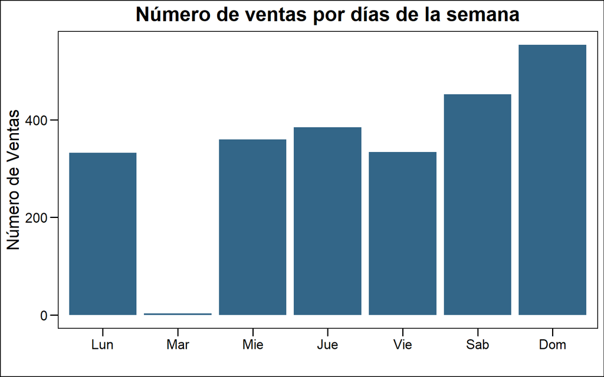

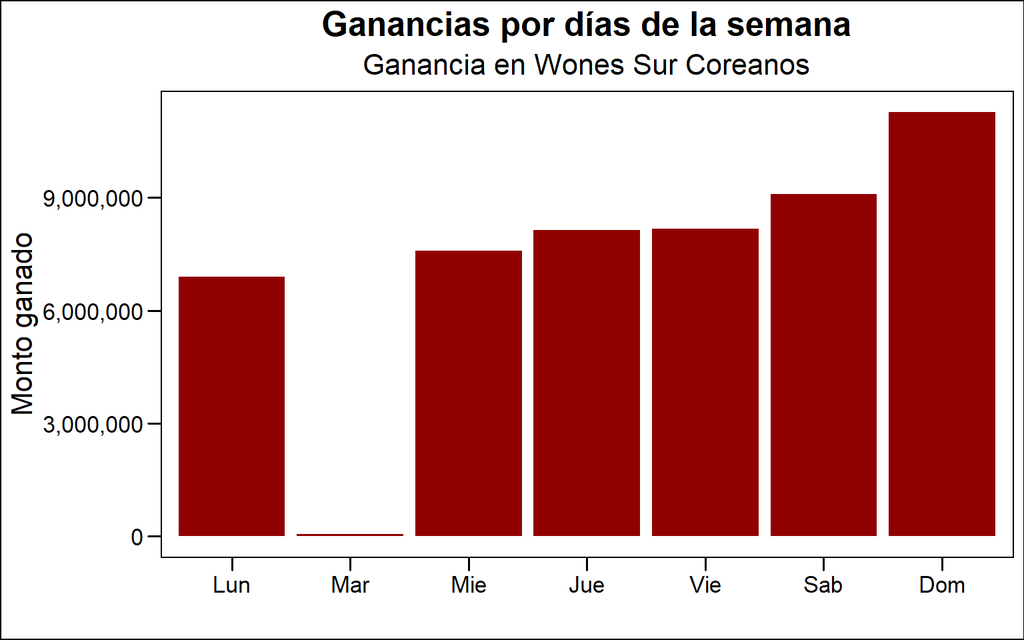

Del gráfico anterior se observa el monto generado en wones sur-coreanos por día. Así se reafirma que los domingos y sábados son los días que generan la mayor cantidad de ingresos para la tienda. Adicionalmente podemos notar que, a medida que la semana termina (si asumimos que parte el lunes), las ganancias aumentan. También se logra visualizar que los viernes, a pesar de ser uno de los días con menor cantidad de ventas, es uno de los que más ganancias genera. Es por eso que, para responder la pregunta, se puede incluir el promedio ponderado de ventas por días de semana, para ver cuál genera mayor ganancia por venta. Esto lo podemos ver en el siguiente gráfico:

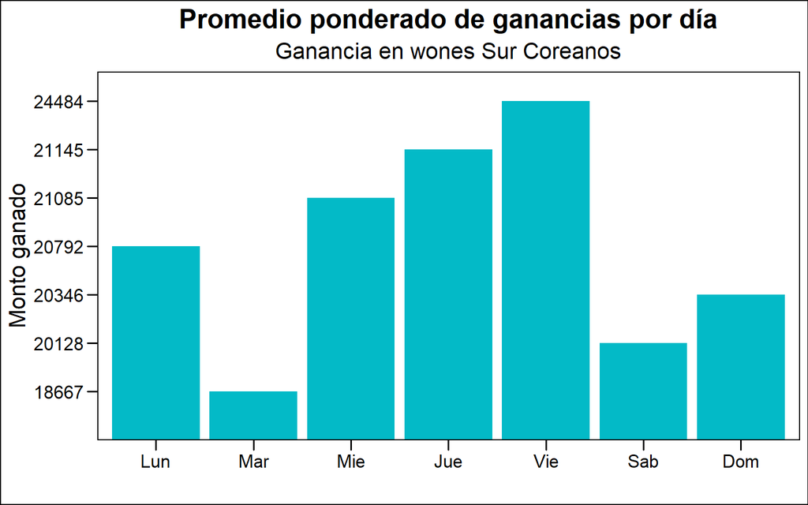

En el gráfico anterior se visualiza el monto promedio de una venta por día. Este promedio se calcula a través del monto total generado dividido en la cantidad de ventas por día. De este gráfico se logra concluir que los viernes es cuando más dinero se gana por venta.

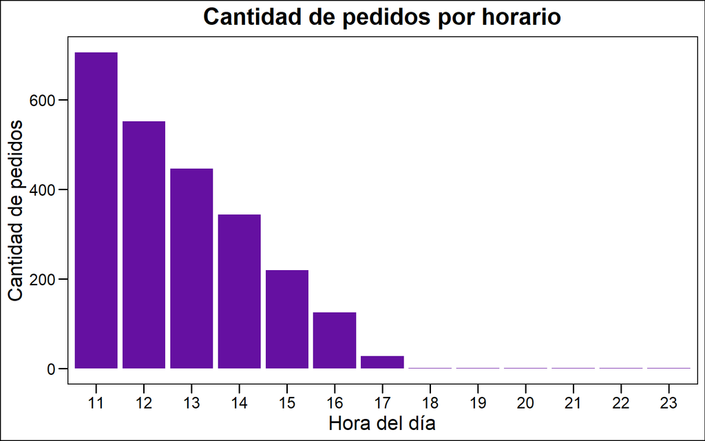

En este gráfico podemos notar que los pedidos se generan con mayor intensidad entre las 11 horas y las 14 horas. Esto se puede explicar debido a que, dentro de muchas rutinas, este horario es utilizado para desayunar, tomar una colación o almorzar. También se puede ver que a pesar de que la tienda cierre a las 23:00, esta no genera muchas solicitudes después de las 18 horas.

Para continuar, podemos analizar lo productos pedidos. Esto nos permite intuir cual producto es el que más se venderá, para luego tener más de estos productos preparados. Para poder responder la pregunta “¿Cuáles son los alimentos preferidos?”, analizaremos los siguientes gráficos separados por bebestibles y comestibles:

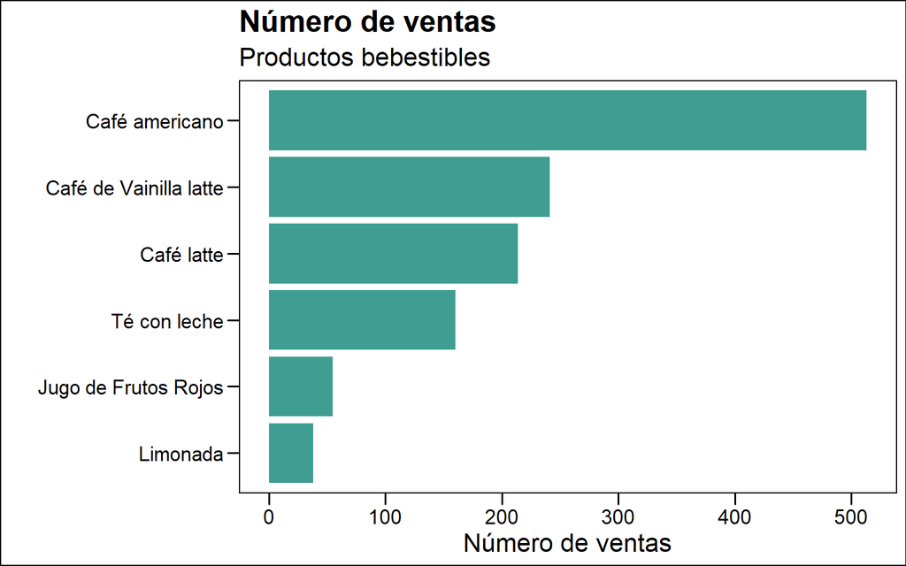

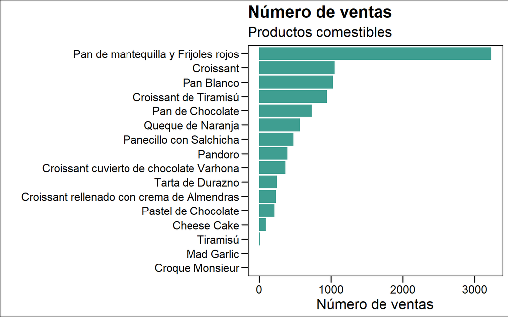

Los gráficos anteriores nos muestran el número de ventas por productos. Del primer gráfico se concluye que, el “Café americano” es el bebestible más vendido. Por otro lado, del segundo gráfico podemos rescatar que, el “Pan de mantequilla con frijoles rojos” es por lejos el producto más vendido.

Dentro de una pastelería se pueden encontrar alimentos dulces y salados, es por eso que se desea ver si el horario nos condiciona a pedir un alimento dulce por sobre un alimento salado. Para responder a la pregunta “¿En qué horarios la gente prefiere productos dulces por sobre los productos salados?”, se analizará el siguiente gráfico:

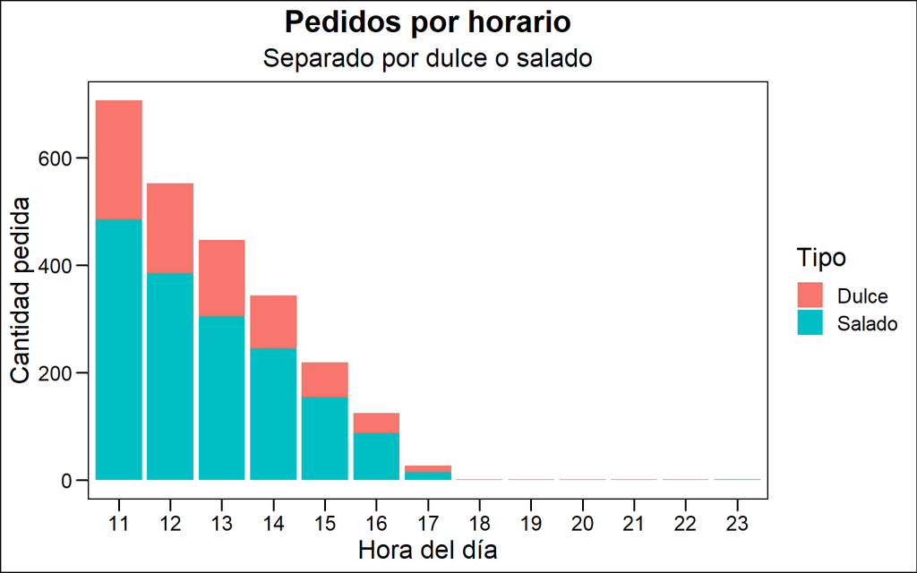

Del gráfico anterior, se logra apreciar que, sin importar el horario, los alimentos del tipo salado siempre serán los que más venden.

Del mismo modo en que hay alimentos dulces y salados, también podemos encontrar una variedad de productos. Por lo que, se verá si el horario afecta a la hora de pedir un producto u otro. Para ello se utilizarán dos gráficos para responder a la pregunta “¿Qué relación hay entre los alimentos más vendidos y el horario?”, los dos gráficos que se analizarán son los siguientes:

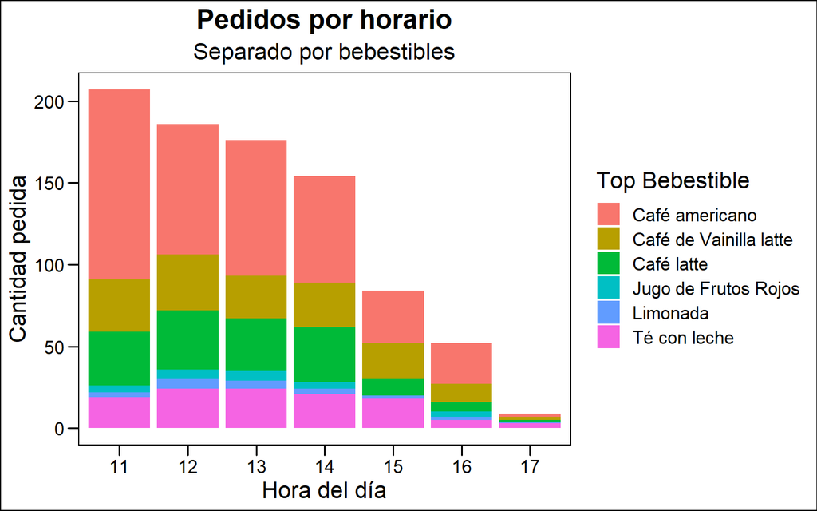

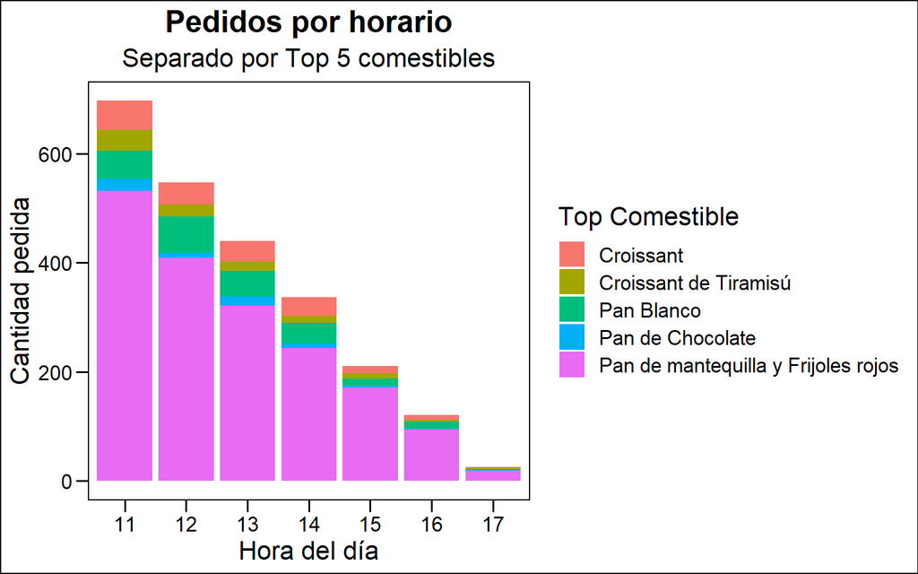

Ambos gráficos contemplan un horario desde las 11:00 hasta las 17:00. Para el gráfico de los bebestibles se compararon todos los bebestibles para visualizar si el horario afecta. Podemos observar que a las 11:00 el “café americano” es el que tiene más de la mitad de las ventas, pero a medida que el día finaliza, el porcentaje de “café americano” por hora disminuye. Por otro lado, en el gráfico que contempla solo los comestibles, podemos notar que, el “pan de mantequilla y frijoles rojos” es el que presenta la mayor cantidad de ventas en todos los horarios, por lo que, sin importar el horario este producto será el que más se venda. Para poder obtener más información utilizaremos tablas. En primer lugar, analizaremos la tabla de ventas por hora de los bebestibles:

|  | **Hora** **11**, N = 207<sup>1</sup> | **Hora** **12**, N = 186<sup>1</sup> | **Hora** **13**, N = 176<sup>1</sup> | **Hora** **14**, N = 154<sup>1</sup> | **Hora** **15**, N = 84<sup>1</sup> | **Hora** **16**, N = 52<sup>1</sup> | **Hora** **17**, N = 9<sup>1</sup> |
| --- | --- | --- | --- | --- | --- | --- | --- |
| Productos |  |  |  |  |  |  |  |
| Café americano | 116 (56%) | 80 (43%) | 83 (47%) | 65 (42%) | 32 (38%) | 25 (48%) | 2 (22%) |
| Café de Vainilla latte | 32 (15%) | 34 (18%) | 26 (15%) | 27 (18%) | 22 (26%) | 11 (21%) | 2 (22%) |
| Café latte | 33 (16%) | 36 (19%) | 32 (18%) | 34 (22%) | 10 (12%) | 6 (12%) | 1 (11%) |
| Jugo de Frutos Rojos | 4 (1,9%) | 6 (3,2%) | 6 (3,4%) | 4 (2,6%) | 0 (0%) | 3 (5,8%) | 0 (0%) |
| Limonada | 3 (1,4%) | 6 (3,2%) | 5 (2,8%) | 3 (1,9%) | 2 (2,4%) | 2 (3,8%) | 1 (11%) |
| Té con leche | 19 (9,2%) | 24 (13%) | 24 (14%) | 21 (14%) | 18 (21%) | 5 (9,6%) | 3 (33%) |

<sup>*1*</sup> Ventas en porcentajes

|  | **Hora** **11**, N = 697<sup>1</sup> | **Hora** **12**, N = 547<sup>1</sup> | **Hora** **13**, N = 440<sup>1</sup> | **Hora** **14**, N = 337<sup>1</sup> | **Hora** **15**, N = 211<sup>1</sup> | **Hora** **16**, N = 121<sup>1</sup> | **Hora** **17**, N = 25<sup>1</sup> |
| --- | --- | --- | --- | --- | --- | --- | --- |
| Productos |  |  |  |  |  |  |  |
| Croissant | 54 (7,7%) | 40 (7,3%) | 38 (8,6%) | 34 (10%) | 13 (6,2%) | 9 (7,4%) | 1 (4,0%) |
| Croissant de Tiramisú | 38 (5,5%) | 22 (4,0%) | 17 (3,9%) | 14 (4,2%) | 10 (4,7%) | 3 (2,5%) | 3 (12%) |
| Pan Blanco | 51 (7,3%) | 67 (12%) | 47 (11%) | 38 (11%) | 13 (6,2%) | 13 (11%) | 1 (4,0%) |
| Pan de Chocolate | 22 (3,2%) | 9 (1,6%) | 17 (3,9%) | 8 (2,4%) | 4 (1,9%) | 2 (1,7%) | 1 (4,0%) |
| Pan de mantequilla y Frijoles rojos | 532 (76%) | 409 (75%) | 321 (73%) | 243 (72%) | 171 (81%) | 94 (78%) | 19 (76%) |

<sup>*1*</sup> Ventas en porcentajes

Podemos ver que el porcentaje del “Pan de mantequilla y frijoles rojos” tiene un porcentaje que no varía tanto durante el día, al igual que en el caso de los bebestibles, el resto no nos da información para concluir que el horario afecta en sus ventas.

## Conclusión

Con los datos obtenidos a través del análisis realizado podemos contestar las preguntas propuestas:

1. ¿Cuáles son los alimentos preferidos?
2. ¿En qué días hay mayores ganancias?
3. ¿Cuál es el rango de horario en el que hay más pedidos?
4. ¿Qué relación hay entre los alimentos más vendidos y el horario?
5. ¿En qué horarios la gente prefiere productos dulces por sobre los productos salados?

Respondiendo a la primera pregunta, sabemos que el “Pan de mantequilla y frijoles rojos” es por lejos el producto más vendido junto a él “Café americano”, el cual es el bebestible más vendido. Para la segunda pregunta tenemos que los días con mayor cantidad de solicitudes son los sábados y domingos, sin embargo, el día que genera mayor cantidad de ganancias por pedido es el viernes. En relación con el horario de los pedidos se tiene que, el horario donde hay más solicitudes es de 11:00 a 14:00, lo que responde a la pregunta 3, para la pregunta 4 se concluye que no hay una relación entre el horario y el producto más vendido (tanto para comestibles como para bebestibles). Por último, no hay horario en donde la gente prefiera productos del tipo dulce por sobre el tipo salado, lo que responde a la pregunta 5.

Con estos datos se pueden tomar muchas decisiones para hacer mejoras en la tienda. Estas decisiones pueden ser separadas en 2 grupos:

1. Cambios en los productos y promociones.
2. Cambios en el horario y personal.

Para el primer grupo se pueden crear promociones para poder incentivar la venta de los productos menos populares como el “Tiramisú” o el “Cheese cake”, por ejemplo, se puede vender el “Pan de mantequilla y frijoles rojos” junto a un “Tiramisú” por un precio menor al que saldría si se vendieran por separado. También se podría crear una promoción para potenciar al “Café americano” con el “Pan de mantequilla y frijoles rojos”, para así atraer a más clientes a la tienda.

Para el segundo grupo se tiene que a partir de las 18 horas no se generan solicitudes, por lo que, en vez de cerrar la tienda a las 23 horas se podría cerrar antes, para destinar más horas a la mañana, horario en el que hay más solicitudes. También se puede realizar un cambio de horario en los turnos del personal o contratar a funcionarios de medio tiempo, para poder hacer frente a un aumento de solicitudes entre las 11 horas y las 14 horas.

En esta pastelería se pueden tomar muchas decisiones con los datos obtenidos a través de los deliveries. Aun así, hay más tipos de datos que pueden ser recopilados a través de los deliveries, por ejemplo, una calificación al pedido para poder obtener información sobre la satisfacción del cliente, o incluso asignar un ID a los clientes para realizar promociones personalizadas y mantener su fidelidad con la tienda. Es por esto que los datos generados por los deliveries tiene una alta relevancia para las tiendas si es que se realiza un buen manejo e interpretación de los datos.

[^1]: Base de datos obtenida de https://www.kaggle.com/hosubjeong/bakery-sales